← Back to index

# Analysis — identities → metrics + plots

## 0. Load extraction bundle

Reads the pre-computed extraction bundle for run **`protein_synthesis_arrested`** from `/Users/vvetshte/Projects/temp/experiments_image/results/protein_synthesis_arrested/extraction` and produces all derived metrics, plots, and the final HTML report.

```
Extraction: 2026-07-30 09:15 UTC (9.9 days ago)  ·  hash 6c4c03b79b51
Loaded 316 tracks, fluor stack (30, 1040, 1388), phase stack (30, 1040, 1388)
```

## Extraction QC

Sanity checks on the extraction the analysis is running against: raw-frame preview, detected cells on frame 0, and frame-quality gating diagnostics. If any of these look off, the downstream metrics do too — re-run extraction with `--force-extract` after adjusting `configs/<run>.yaml::extraction`.

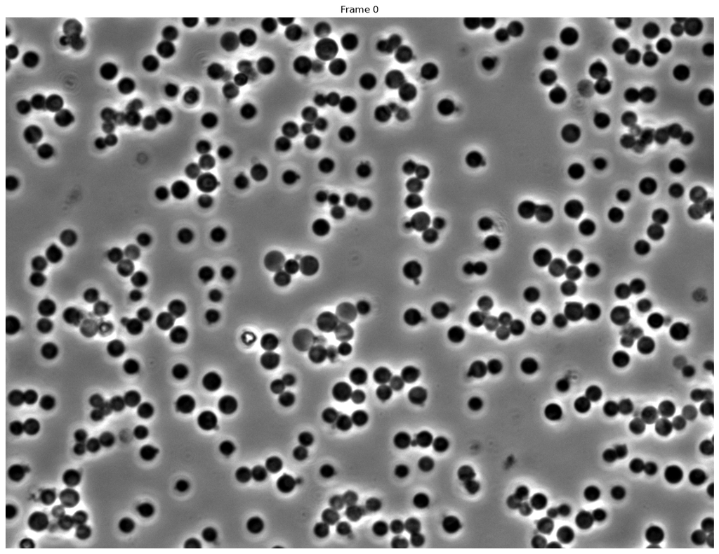

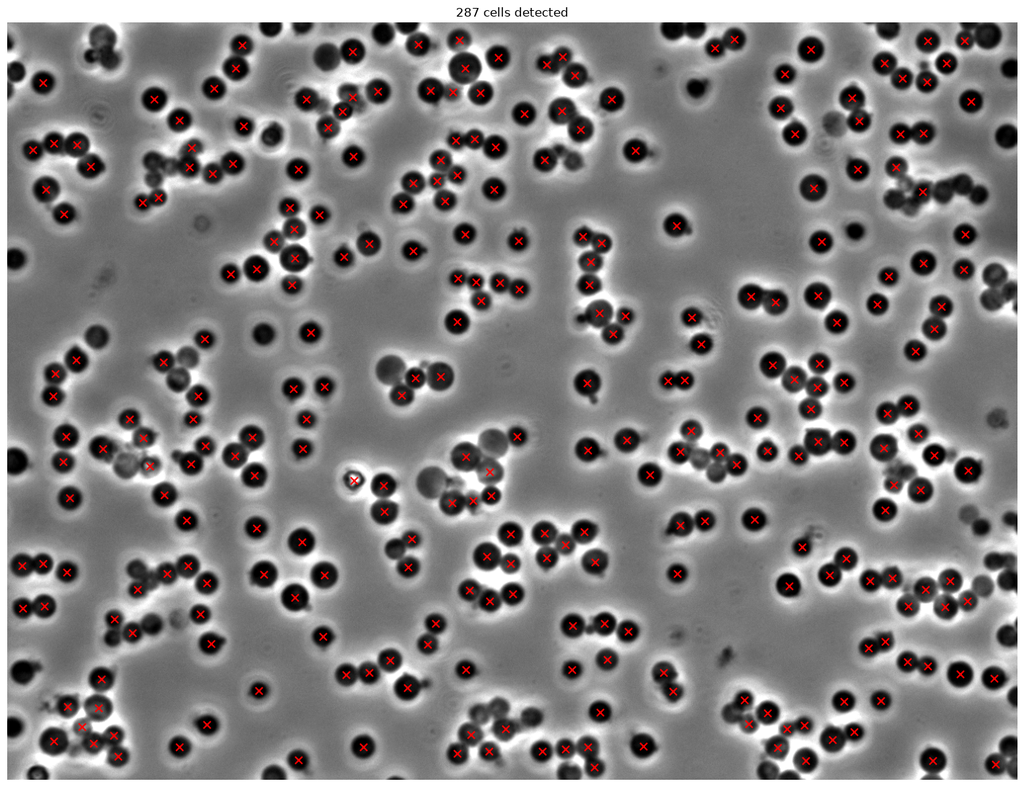

```
Bad frames: none
No frames dropped — all frames passed quality gating.
```

[interactive chart not shown]

## 1. Fluorescence measurement

## 6. Statistics and Plots

### 6.1 Cell count per frame

[interactive chart not shown]

```
Initial count (frame 0): 287
Final count (frame 29): 23
Fraction disappeared: 92.0%
50% disappearance frame: 16
```

*Source: `tracked_cells.csv`*

### 6.2 Lifetime distribution and disappearance

```
Total tracks: 316
Survived to final frame: 23 (7.3%)
Disappeared: 293 (92.7%)
Disappeared lifetime — median: 15, mean: 15.2 ± 4.4 frames
```

[interactive chart not shown]

```
Frame of maximum disappearance: 12
Cells lost at peak: 32
```

*Source: `track_statistics.csv`*

### 6.3 Cell area distribution

Histogram pooled over the first `BASELINE_FRAMES` frames (before medium changes drive swelling). Areas are in µm² after the `PIXEL_SIZE_UM` rescale applied in `add_geometry`. Set `BASELINE_FRAMES = 1` to recover frame-0-only.

[interactive chart not shown]

```
Median area:         4.08 µm²
Median volume:       6.20 µm³
Median surface area: 16.32 µm²
```

*Source: `tracked_cells.csv`*

### 6.4 Relative swelling dynamics V(t)/V(0) and S(t)/S(0)

Population-averaged relative volume and surface area change over time. Only tracks present at frame 0 are included (initial population with known baseline). Shaded band shows mean +/- SEM. Faint individual traces from a random subset of 20 cells shown for context.

```
Tracks starting at frame 0: 287
```

[interactive chart not shown]

```
Final V(t)/V(0) at frame 29: 2.086 ± 0.157
Final S(t)/S(0) at frame 29: 1.613 ± 0.083
Cells contributing at final frame: 19
```

*Source: `tracked_cells.csv`*

### 6.5 Swelling extent vs. initial cell size and survival

Left: does the magnitude of swelling depend on initial cell volume? Each dot is one frame-0 track; the x-axis is V(0), the y-axis is the maximum V(t)/V(0) reached during that track's lifetime.

Right: do cells that disappear (lyse) swell differently from those that survive? Population-averaged V(t)/V(0) curves split by outcome.

**Why disappeared cells show lower median max swelling but higher curves at late frames:** Disappeared cells burst early — many leave by frame 10-15 and had fewer frames to accumulate volume, so their lifetime peak is lower. The right panel shows the opposite at late frames because of survivorship bias: the only disappeared cells still tracked at frames 20+ are the extreme swellers that haven't burst yet. Both views are correct — they measure different things (lifetime peak vs. instantaneous population mean).

A more comparable metric is **swelling rate per frame** (printed below), which normalizes for lifetime differences.

[interactive chart not shown]

```
Frame-0 cohort: 19 survived, 268 disappeared
Mean initial volume (survived):    6.44 ± 1.82 µm³
Mean initial volume (disappeared): 5.98 ± 1.92 µm³
Median max swelling (survived):    2.124x
Median max swelling (disappeared): 1.568x
Median swelling rate (survived):    0.0375x per frame
Median swelling rate (disappeared): 0.0352x per frame
```

*Source: `tracked_cells.csv`*

### 6.5b Relative swelling V(t)/V(0) vs. normalized lifespan, by fate

Three views: per-frame mean ± SEM, lifespan-normalized average split by fate, and frame-axis split by fate. Same panel layout as the CV/nNRM dynamics in §8.4–§8.5.

[interactive chart not shown]

```
V(t)/V(0) at frame 0: 1.000
V(t)/V(0) at frame 29: 2.138
```

*Sources: `tracked_cells.csv`, `track_statistics.csv`*

## 7. Fluorescence Preview

Background-subtracted fluorescence stack, aligned frame-by-frame with the phase-contrast stack. Bad frames already have zeroed label masks from gating.

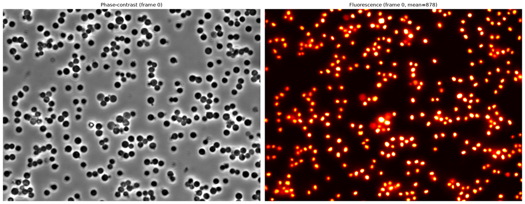

## 8. Fluorescence Quantification and Dynamics

Measures fluorescence intensity and distribution metrics within each phase-contrast cell mask. Metrics per cell per frame:

| Metric | Description |
| --- | --- |
| mean/total/min/max intensity | Basic intensity statistics |
| CV (std/mean) | Nucleoid heterogeneity — high = concentrated, low = dispersed |
| nNRM (KS statistic) | Non-normality of pixel distribution (Gough et al. 2014) |
| skewness, kurtosis | Distribution shape descriptors |

```
Fluorescence measurements: 4936 rows
Matched 4901/4901 detections (100.0%) with fluorescence
Median fluorescence intensity per track: 2211
Median CV per track: 0.646
Median nNRM per track: 0.147
```

```
Nucleoid distribution: 4901/4901 cell-frames measured
```

### 8.1 Population mean fluorescence per frame

[interactive chart not shown]

```
Frame 0 mean fluorescence: 2960
Frame 29 mean fluorescence: 867
Change: 0.29x
```

*Source: `tracked_cells.csv`*

### 8.2 Relative fluorescence F(t)/F(0)

Same frame-0 cohort used for swelling analysis. Shows how fluorescence changes relative to each cell's initial value. Disappeared vs survived split reveals whether fluorescence predicts cell fate.

[interactive chart not shown]

```
Final F(t)/F(0): 0.294 +/- 0.038
Cells contributing at final frame: 19
```

*Source: `tracked_cells.csv`*

### 8.2b Relative fluorescence F(t)/F(0) vs. normalized lifespan, by fate

Companion to §6.5b — same three panels for fluorescence.

[interactive chart not shown]

```
F(t)/F(0) at frame 0: 1.000
F(t)/F(0) at frame 29: 0.320
```

*Sources: `tracked_cells.csv`, `track_statistics.csv`*

### 8.3 Fluorescence vs. swelling correlation

Does fluorescence intensity track with cell volume? Each point is one cell at one frame. A positive correlation suggests fluorescence scales with cell size (membrane or cytoplasmic stain); no correlation suggests a localized signal (e.g., nuclear).

[interactive chart not shown]

*Source: `tracked_cells.csv`*

### 8.4 Nucleoid heterogeneity: CV dynamics

CV (coefficient of variation = std/mean of pixel intensities within each cell mask) measures nucleoid spatial concentration. High CV = bright nucleoid spots on dark cytoplasmic background (intact, concentrated). Low CV = more uniform distribution (dispersed nucleoid).

Three views: absolute per frame, lifespan-normalized (all tracks aligned to [0,1]), and disappeared vs survived.

[interactive chart not shown]

```
CV at frame 0: 0.752
CV at frame 29: 0.506
```

*Sources: `tracked_cells.csv`, `track_statistics.csv`*

### 8.4c Nucleoid edge-distance dynamics

Mean distance of suprathreshold fluorescence pixels from the cell-mask edge, normalized by R/3 (the expected mean-edge-distance for points uniformly distributed inside a circle of radius R). Values > 1 ⇒ pixels clustered toward the center; values < 1 ⇒ pixels at the periphery ("horseshoe"). Approaches 1 as the nucleoid disperses with swelling.

[interactive chart not shown]

```
Edge-dist / (R/3) at frame 0: 1.700
Edge-dist / (R/3) at frame 29: 1.533
```

*Sources: `tracked_cells.csv`, `track_statistics.csv`*

### 8.5 Non-Normality Index (nNRM) dynamics

nNRM = Kolmogorov-Smirnov statistic comparing pixel intensity distribution against a Gaussian with matching mean and std (Gough et al. 2014, PLOS ONE). Range [0, 1]: 0 = Gaussian, 1 = maximally non-Gaussian. Complements CV — CV measures spread, nNRM measures distribution shape. A high nNRM indicates distinct subpopulations within the cell mask (bright nucleoid vs dark cytoplasm).

[interactive chart not shown]

```
nNRM at frame 0: 0.170
nNRM at frame 29: 0.093
```

*Sources: `tracked_cells.csv`, `track_statistics.csv`*

### 8.5b Nucleoid spatial σ dynamics

σ of the 2D intensity-weighted spatial distribution of suprathreshold pixels (mean of eigenvalues of the weighted covariance), normalized by the cell's pixel-space R. Captures dispersion: small σ ⇒ tight cluster; large σ ⇒ spread across the cell.

[interactive chart not shown]

```
σ / R at frame 0: 0.281
σ / R at frame 29: 0.342
```

*Sources: `tracked_cells.csv`, `track_statistics.csv`*

### 8.5c Peri/core asymmetry dynamics

Signed asymmetry index `(I_peri − I_core) / (I_peri + I_core)` where the two regions are set by `PERI_CORE_RINGS = (core_max, peri_min, peri_max)` as fractions of the cell's equivalent radius R. Default `(0.15, 0.35, 0.55)` — narrow core samples the donut center dip, peri brackets the donut peak zone identified from real radial profiles (see `docs/peri_core_asymmetry_definition_history.md` for the sweep and the historical parameter sets). The intermediate band and the outer rim are ignored. Bounded in [−1, 1]:

- **positive** → edge-clustered (expanded / donut-shaped nucleoid),
- **negative** → center-clustered (compacted nucleoid),
- **0** → radially uniform.

Areas are unequal, so mean rather than total intensity is used in each ring. Uses raw (unthresholded) intensities so the metric is defined even for near-uniform cells. Complements §8.4c (edge distance) and §8.5b (σ) — same three-panel layout by fate.

[interactive chart not shown]

```
Peri/core asymmetry at frame 0: -0.222
Peri/core asymmetry at frame 29: -0.087
```

*Sources: `tracked_cells.csv`, `track_statistics.csv`*

### 8.5d Peri/core asymmetry aligned to phase disappearance

Per-cell trajectory of `peri_core_asymmetry` in the window [-`FLUOR_ALIGN_WINDOW`, 0] frames before each disappeared cell's last detection. Complements §8.5c by removing the averaging-across-frames artifact: cells caught at absolute frame N are at different stages of their own life cycle, so a per-frame median smears the trajectory. Aligning by offset from last-detected frame puts every cell on the same timeline relative to burst.

- **Left panel**: individual trajectories (thin blue), median + IQR band across cells. Shows whether initial donut/sparse phenotypes converge to a common pre-burst state.
- **Right panel**: baseline (offset -N) vs. last-frame (offset 0) scatter, one dot per cell. Points off the diagonal indicate a transformation between initial and pre-burst states.

[interactive chart not shown]

```
Aligned 281 disappeared tracks (window=-5..0)
  offset -5: median asymmetry = -0.148
  offset -4: median asymmetry = -0.147
  offset -3: median asymmetry = -0.143
  offset -2: median asymmetry = -0.142
  offset -1: median asymmetry = -0.130
  offset +0: median asymmetry = -0.110
```

*Source: `peri_core_alignment.csv`*

### 8.6 Fluorescence dynamics around phase disappearance

Fluorescence loss is rarely instantaneous and rarely aligned with the phase mask vanishing — DNA exits through membrane pores more slowly than proteins, and the lysis itself can take multiple frames. To make this visible, for each `disappeared` cell we align its mean intensity to its last phase-detection frame and plot the ±`FLUOR_ALIGN_WINDOW` frames around that anchor.

Post-disappearance frames (offset > 0) use the cell's **final phase mask** to integrate fluorescence — the cell's last known ROI applied to subsequent fluorescence frames.

[interactive chart not shown]

```
Aligned 281 disappeared tracks (window=+/-5)
  offset -5: median F_norm = 1.000
  offset -4: median F_norm = 0.941
  offset -3: median F_norm = 0.928
  offset -2: median F_norm = 0.925
  offset -1: median F_norm = 0.858
  offset +0: median F_norm = 0.691
  offset +1: median F_norm = 0.101
  offset +2: median F_norm = 0.068
  offset +3: median F_norm = 0.063
  offset +4: median F_norm = 0.055
  offset +5: median F_norm = 0.052
```

*Source: `fluorescence_alignment.csv`*

### 8.9 Fluorescence concentration (dilution-corrected)

Raw fluorescence intensity confounds true signal changes with dilution from cell swelling — a cell that doubles in volume halves its concentration even if total fluorophore content stays constant. Fluorescence concentration (`total_intensity / volume`) corrects for this, revealing whether fluorescence changes are biological or geometric.

```
Fluorescence concentration: 4901/4901 cells computed
```

[interactive chart not shown]

```
Frame 0 mean concentration: 481875.319
Frame 29 mean concentration: 111897.360
Change: 0.23x
```

*Source: `tracked_cells.csv`*

### 8.11 Surface-area-to-volume ratio

SA:V ratio is a proxy for membrane mechanical stress. As cells swell (volume increases faster than surface area for a sphere), SA:V decreases — the membrane must stretch to accommodate the growing volume. Lower SA:V may indicate cells closer to their mechanical rupture threshold.

```
SA:V ratio: 4901/4901 cells computed
Median SA:V at frame 0: 2.6875
```

[interactive chart not shown]

```
SA:V at frame 0: 2.7211
SA:V at frame 29: 2.1675
Median SA:V at death: 2.3710
Median SA:V at end (survived): 2.0694
```

*Sources: `tracked_cells.csv`, `track_statistics.csv`*

### 8.13 Pre-burst fluorescence behavior

Does fluorescence change in the frames immediately before a cell disappears? For each disappeared track, fits a linear trend to mean fluorescence intensity in a 5-frame window before the last detection. A positive slope with intensity exceeding baseline indicates a pre-burst "spike" — possible membrane permeabilization allowing dye influx before final rupture.

```
Pre-burst fluorescence (5-frame window):
  Tracks with pre-burst spike: 8/293 (3%)
```

[interactive chart not shown]

```
Median pre-burst slope: -73.03
Cells with pre-burst spike: 8/293
```

*Sources: `tracked_cells.csv`, `track_statistics.csv`*

### 8.14 Cell fate prediction from frame-0 features

Can we predict which cells will die just from their appearance at frame 0? Two complementary tests on the **frame-0 cohort** (cells visible at `frame == 0`, labelled by their eventual `disappeared` flag from `track_statistics.csv`):

The Mann-Whitney table tests each feature in isolation; the logistic regression asks whether the five together can rank cells by death probability (ROC curve + feature importance).

**Related views of the same question, elsewhere in the report:**

- §8.17 Initial fluorescence features vs. lifespan — same frame-0 features, but plotted against the *continuous* lifetime variable with Spearman rho. Mann-Whitney here, Spearman there.
- §6.5 Swelling extent vs. initial cell size and survival — initial volume vs. eventual fate (V(0) split by survived/disappeared).

```
Frame-0 features by fate (Mann-Whitney U, two-sided):
  Cohort: 19 survived, 268 died
   area: median 4.060 (surv) vs 3.904 (died) [↓ died], U=2195, p=3.16e-01
     cv: median 0.733 (surv) vs 0.775 (died) [↑ died], U=3070, p=1.34e-01
   nnrm: median 0.168 (surv) vs 0.175 (died) [↑ died], U=3084, p=1.24e-01
  mean_edge_distance_norm: median 1.714 (surv) vs 1.721 (died) [↑ died], U=2618, p=8.38e-01
  gaussian_sigma_norm: median 0.282 (surv) vs 0.279 (died) [↓ died], U=2124, p=2.28e-01
```

|  | feature | n_survived | n_died | median_survived | median_died | U | p_value |
| --- | --- | --- | --- | --- | --- | --- | --- |
| 0 | area | 19 | 268 | 4.060404 | 3.904395 | 2195.0 | 0.316038 |
| 1 | cv | 19 | 268 | 0.732948 | 0.774969 | 3070.0 | 0.134263 |
| 2 | nnrm | 19 | 268 | 0.168102 | 0.175314 | 3084.0 | 0.124159 |
| 3 | mean_edge_distance_norm | 19 | 268 | 1.713953 | 1.720592 | 2618.0 | 0.837940 |
| 4 | gaussian_sigma_norm | 19 | 268 | 0.281719 | 0.279060 | 2124.0 | 0.227924 |

```
Fate prediction (LOO cross-validation, n=287):
  AUC: 0.545
  Accuracy: 93.4%
  Died: 268, Survived: 19
  Feature importance (z-scored coefficients):
    area: -0.345 (↓ death)
    cv: -0.068 (↓ death)
    nnrm: +0.547 (↑ death)
    mean_edge_distance_norm: -0.398 (↓ death)
    gaussian_sigma_norm: -0.337 (↓ death)
  Per-class performance (probability threshold 0.5):
    survived     (n= 19): precision=0.000, recall=0.000, f1=0.000
    disappeared  (n=268): precision=0.934, recall=1.000, f1=0.966
  Confusion matrix (rows = actual, cols = predicted):
                              pred: survived  pred: disappeared
    actual: survived                0            19
    actual: disappeared             0           268
```

```
Fate prediction (LOO cross-validation, n=287):
  AUC: 0.524
  Accuracy: 93.4%
  Died: 268, Survived: 19
  Feature importance (z-scored coefficients):
    cv: -0.165 (↓ death)
    nnrm: +0.384 (↑ death)
    mean_edge_distance_norm: -0.490 (↓ death)
    gaussian_sigma_norm: -0.532 (↓ death)
  Per-class performance (probability threshold 0.5):
    survived     (n= 19): precision=0.000, recall=0.000, f1=0.000
    disappeared  (n=268): precision=0.934, recall=1.000, f1=0.966
  Confusion matrix (rows = actual, cols = predicted):
                              pred: survived  pred: disappeared
    actual: survived                0            19
    actual: disappeared             0           268
```

[interactive chart not shown]

*Sources: `fate_predictions.csv`, `fate_prediction_summary.csv`*

```
Feature-set comparison:
                        full (5)   no-area (4)
  AUC                   0.545      0.524
  Accuracy              0.934      0.934
  Recall (survived)     0.000      0.000
  Recall (disappeared)  1.000      1.000
  F1 (survived)         0.000      0.000
  F1 (disappeared)      0.966      0.966
  (differences small; full feature set remains the default)
```

### 8.16 Nucleus persistence after cell lysis

Do fluorescent nuclei (DNA) survive as discrete objects after the cell membrane ruptures? To test this, we independently segment the fluorescence channel with Cellpose and compare object counts frame-by-frame against phase-contrast cells.

If nuclei persist after lysis, fluorescence counts should decline slower than phase counts (growing offset). If they disperse immediately, both should decline in parallel (constant offset).

```
Phase cells lost (first to last frame): 269
Fluor nuclei lost (first to last frame): 312
Difference std across frames: 12.6

Conclusion: Divergent decline — nuclei may persist after lysis (total loss diverged (269 vs 312); offset CV too high (0.34 >= 0.3))
```

[interactive chart not shown]

```
Phase vs fluor count: Pearson r = 0.997, p = 3.36e-32
```

*Sources: `nucleus_persistence.csv`, `nucleus_persistence_summary.csv`*

### 8.17 Initial fluorescence features vs. lifespan

Implementation: `plot_initial_features_vs_lifespan()` in `src/cell_analysis/plotting.py`.

[interactive chart not shown]

```
Initial fluorescence vs lifetime: Spearman rho = -0.057, p = 3.40e-01
Initial CV vs lifetime: Spearman rho = 0.064, p = 2.78e-01
Initial nNRM vs lifetime: Spearman rho = 0.013, p = 8.29e-01
```

*Sources: `tracked_cells.csv`, `track_statistics.csv`*

## 9. Export Results

Each CSV is saved inline by the cell that produces it, so the source link under each plot resolves at the moment the plot is rendered. The cell below lists every CSV currently on disk.

| File | Contents |
| --- | --- |
| `tracked_cells.csv` | Per-cell per-frame: morphology (area/volume/SA in µm), volume_rel, fluorescence, fluor_rel, fluor_concentration, sav_ratio |
| `track_statistics.csv` | Per-track summary: lifetime, mean geometry, mean fluorescence (intensity/CV/nNRM), fluorescence-drop frame, pre-burst slope |
| `fluorescence_alignment.csv` | Long-form per-disappeared-cell F(t) trace aligned to last detection frame (offset -window..+window) |
| `peri_core_alignment.csv` | Long-form per-disappeared-cell peri_core_asymmetry aligned to last detection frame (offset -window..0). Delta_from_baseline column = trajectory relative to earliest observation. |
| `frame_diagnostics.csv` | Per-frame detection statistics and gating flags |
| `merge_log.csv` | Track merging audit log (which fragments were absorbed into which tracks) |
| `frame0_fate_comparison.csv` | Per-feature Mann-Whitney U on area/CV/nNRM, survived vs disappeared (frame-0 cohort) |
| `fate_predictions.csv` | Per-cell predicted death probability and class (frame-0 cohort) |
| `fate_prediction_summary.csv` | Single-row: AUC, accuracy, per-feature coefficients |
| `fate_predictions_no_area.csv` | Same as `fate_predictions.csv` but for the 4-feature LR (no `area`) |
| `fate_prediction_summary_no_area.csv` | Single-row: AUC, accuracy, per-class metrics, per-feature coefficients for the no-area model |
| `nucleus_persistence.csv` | Per-frame phase cell vs fluorescence nucleus counts |
| `nucleus_persistence_summary.csv` | Single-row: loss counts, offset CV, conclusion |
| `dropped_frames.csv` | Flagged frames only (created by frame gating if any frames flagged) |

```
Saved 11 files to results/protein_synthesis_arrested/
  fate_prediction_summary.csv
  fate_prediction_summary_no_area.csv
  fate_predictions.csv
  fate_predictions_no_area.csv
  fluorescence_alignment.csv
  frame0_fate_comparison.csv
  nucleus_persistence.csv
  nucleus_persistence_summary.csv
  peri_core_alignment.csv
  track_statistics.csv
  tracked_cells.csv
```

## 10. Export HTML Report

Saves the notebook to disk and exports a self-contained HTML copy to `results/<RUN_NAME>/report.html`. Set `EXPORT_HTML = False` (top of notebook) to skip. The CLI runner (`scripts/run_experiment.py`) uses the same exporter, so interactive and CLI reports stay in sync.